# **Introduction:**

- The NBA MVP is an award that is given out to the most valuable player of the regular season ever since the year 1956. It is the most prestegious individual award in the sport of basketball and it serves as a way to deterime who are some of the greatest players of all time in the sport.
- While who wins the MVP vote remains subjective and there is no clear cut formula, with the increased player data & player statistics that is available we hope to understand what factors seperate the MVP of a season from Non-MVP's.
- This information is valuable for sports bettors because the MVP Line is among one of the most saught after betting lines. Having this information can set them up for success in terms of gaining a slight edge compared to the unassisted eye. It is also valuable information for sports brodcasters so they can notice who to focus on when currating content and talking about the current greatest NBA players.
- This brings us to the question we aim to answer: **What seperates the NBA MVP?**

# **Data Curation:**

**Dataset:**

- We need information on historically what has been the pattern for MVP Selection.
- We are including a dataset we found on Kaggle which is the NBA MVP Data containing information for the playing statistics for the NBA MVP Candidates from 1991-2021. This data includes information for the MVP Candidates and the actual MVP for each of the seasons in the range from 1991-2021. This way the model can pick up on what differentiates an MVP in a particular season.
- Data Source: https://www.kaggle.com/datasets/vivovinco/19912021-nba-stats?select=mvps.csv

```python
import pandas as pd
mvp_df = pd.read_csv("mvps.csv", encoding="latin-1", delimiter=";")
mvp_df.head()
```

|  | Rank | Player | Age | Tm | First | Pts Won | Pts Max | Share | G | MP | ... | TRB | AST | STL | BLK | FG% | 3P% | FT% | WS | WS/48 | Year |
| --- | --- | --- | --- | --- | --- | --- | --- | --- | --- | --- | --- | --- | --- | --- | --- | --- | --- | --- | --- | --- | --- |
| 0 | 1 | Michael Jordan | 27 | CHI | 77 | 891 | 960 | 0.928 | 82 | 37.0 | ... | 6.0 | 5.5 | 2.7 | 1.0 | 0.539 | 0.312 | 0.851 | 20.3 | 0.321 | 1991 |
| 1 | 2 | Magic Johnson | 31 | LAL | 10 | 497 | 960 | 0.518 | 79 | 37.1 | ... | 7.0 | 12.5 | 1.3 | 0.2 | 0.477 | 0.320 | 0.906 | 15.4 | 0.251 | 1991 |
| 2 | 3 | David Robinson | 25 | SAS | 6 | 476 | 960 | 0.496 | 82 | 37.7 | ... | 13.0 | 2.5 | 1.5 | 3.9 | 0.552 | 0.143 | 0.762 | 17.0 | 0.264 | 1991 |
| 3 | 4 | Charles Barkley | 27 | PHI | 2 | 222 | 960 | 0.231 | 67 | 37.3 | ... | 10.1 | 4.2 | 1.6 | 0.5 | 0.570 | 0.284 | 0.722 | 13.4 | 0.258 | 1991 |
| 4 | 5 | Karl Malone | 27 | UTA | 0 | 142 | 960 | 0.148 | 82 | 40.3 | ... | 11.8 | 3.3 | 1.1 | 1.0 | 0.527 | 0.286 | 0.770 | 15.5 | 0.225 | 1991 |

5 rows × 21 columns

- Before we can proceed we must perform One-Hot-Encoding to convert catagorical variables to numerical values for the MVP. Since First contains information on the number of votes each player recieved, for a given year the person with the highest value in the First column is the MVP.
- We are going to utilize One Hot Encoding to come up with a catagorical column that tracks whether that specific person was the MVP or not assinging a value of 1 for rows with the MVP and 0 to rows without the MVP.

```python
mvp_index = mvp_df.groupby('Year')['First'].idxmax()
mvp_df['is_mvp'] = 0
mvp_df.loc[mvp_index, 'is_mvp'] = 1
mvp_df.head()
```

|  | Rank | Player | Age | Tm | First | Pts Won | Pts Max | Share | G | MP | ... | AST | STL | BLK | FG% | 3P% | FT% | WS | WS/48 | Year | is_mvp |
| --- | --- | --- | --- | --- | --- | --- | --- | --- | --- | --- | --- | --- | --- | --- | --- | --- | --- | --- | --- | --- | --- |
| 0 | 1 | Michael Jordan | 27 | CHI | 77 | 891 | 960 | 0.928 | 82 | 37.0 | ... | 5.5 | 2.7 | 1.0 | 0.539 | 0.312 | 0.851 | 20.3 | 0.321 | 1991 | 1 |
| 1 | 2 | Magic Johnson | 31 | LAL | 10 | 497 | 960 | 0.518 | 79 | 37.1 | ... | 12.5 | 1.3 | 0.2 | 0.477 | 0.320 | 0.906 | 15.4 | 0.251 | 1991 | 0 |
| 2 | 3 | David Robinson | 25 | SAS | 6 | 476 | 960 | 0.496 | 82 | 37.7 | ... | 2.5 | 1.5 | 3.9 | 0.552 | 0.143 | 0.762 | 17.0 | 0.264 | 1991 | 0 |
| 3 | 4 | Charles Barkley | 27 | PHI | 2 | 222 | 960 | 0.231 | 67 | 37.3 | ... | 4.2 | 1.6 | 0.5 | 0.570 | 0.284 | 0.722 | 13.4 | 0.258 | 1991 | 0 |
| 4 | 5 | Karl Malone | 27 | UTA | 0 | 142 | 960 | 0.148 | 82 | 40.3 | ... | 3.3 | 1.1 | 1.0 | 0.527 | 0.286 | 0.770 | 15.5 | 0.225 | 1991 | 0 |

5 rows × 22 columns

- For easier understanding, we are also going to rename the names of the columns.

```python
mvp_df = mvp_df.rename(columns={'G': 'Games_Played', 'MP': 'Minutes_Per_Game','PTS':'Points_Per_Game', 'TRB': 'Rebounds_Per_Game', 'STL':'Steals_Per_Game','AST':'Assists_Per_Game', 'STL':'Steals_Per_Game', 'BLK':'Blocks_Per_Game'})
mvp_df.head()
```

|  | Rank | Player | Age | Tm | First | Pts Won | Pts Max | Share | Games_Played | Minutes_Per_Game | ... | Assists_Per_Game | Steals_Per_Game | Blocks_Per_Game | FG% | 3P% | FT% | WS | WS/48 | Year | is_mvp |
| --- | --- | --- | --- | --- | --- | --- | --- | --- | --- | --- | --- | --- | --- | --- | --- | --- | --- | --- | --- | --- | --- |
| 0 | 1 | Michael Jordan | 27 | CHI | 77 | 891 | 960 | 0.928 | 82 | 37.0 | ... | 5.5 | 2.7 | 1.0 | 0.539 | 0.312 | 0.851 | 20.3 | 0.321 | 1991 | 1 |
| 1 | 2 | Magic Johnson | 31 | LAL | 10 | 497 | 960 | 0.518 | 79 | 37.1 | ... | 12.5 | 1.3 | 0.2 | 0.477 | 0.320 | 0.906 | 15.4 | 0.251 | 1991 | 0 |
| 2 | 3 | David Robinson | 25 | SAS | 6 | 476 | 960 | 0.496 | 82 | 37.7 | ... | 2.5 | 1.5 | 3.9 | 0.552 | 0.143 | 0.762 | 17.0 | 0.264 | 1991 | 0 |
| 3 | 4 | Charles Barkley | 27 | PHI | 2 | 222 | 960 | 0.231 | 67 | 37.3 | ... | 4.2 | 1.6 | 0.5 | 0.570 | 0.284 | 0.722 | 13.4 | 0.258 | 1991 | 0 |
| 4 | 5 | Karl Malone | 27 | UTA | 0 | 142 | 960 | 0.148 | 82 | 40.3 | ... | 3.3 | 1.1 | 1.0 | 0.527 | 0.286 | 0.770 | 15.5 | 0.225 | 1991 | 0 |

5 rows × 22 columns

- Feature Engineering: We will also remove certain columns reducing the dimensionality of our data so that our Machine Learning Model is more efficient and it will also assists us from a data visualization aspect towards the end.
- We will be using domain knowledge to reduce the dimension of this data

Reason for removing values:

- Rank: Simply serves as index
- Team: NBA MVP Vote is unbaised and does not depend on what team player is playing for
- First, Pts Won, Pts Max, Share: These column values reffer to statistics gathered during the MVP Voting Process
- WS: This value can be developed from the values in column WS/48 so no need to repeat it again

```python
columns_to_drop = ['Rank','Tm', 'First', 'WS', 'Pts Won', 'Pts Max', 'Share']
mvp_df = mvp_df.drop(columns=columns_to_drop)
mvp_df.head()
```

|  | Player | Age | Games_Played | Minutes_Per_Game | Points_Per_Game | Rebounds_Per_Game | Assists_Per_Game | Steals_Per_Game | Blocks_Per_Game | FG% | 3P% | FT% | WS/48 | Year | is_mvp |
| --- | --- | --- | --- | --- | --- | --- | --- | --- | --- | --- | --- | --- | --- | --- | --- |
| 0 | Michael Jordan | 27 | 82 | 37.0 | 31.5 | 6.0 | 5.5 | 2.7 | 1.0 | 0.539 | 0.312 | 0.851 | 0.321 | 1991 | 1 |
| 1 | Magic Johnson | 31 | 79 | 37.1 | 19.4 | 7.0 | 12.5 | 1.3 | 0.2 | 0.477 | 0.320 | 0.906 | 0.251 | 1991 | 0 |
| 2 | David Robinson | 25 | 82 | 37.7 | 25.6 | 13.0 | 2.5 | 1.5 | 3.9 | 0.552 | 0.143 | 0.762 | 0.264 | 1991 | 0 |
| 3 | Charles Barkley | 27 | 67 | 37.3 | 27.6 | 10.1 | 4.2 | 1.6 | 0.5 | 0.570 | 0.284 | 0.722 | 0.258 | 1991 | 0 |
| 4 | Karl Malone | 27 | 82 | 40.3 | 29.0 | 11.8 | 3.3 | 1.1 | 1.0 | 0.527 | 0.286 | 0.770 | 0.225 | 1991 | 0 |

# **Exploratory Data Analysis:**

**Outlier Detection:**

- We will create a BoxPlot of the Points Per Game(PTS) and notice the presence of any outlier and remove these outliers in the following section.
- This simple statistic is among the most recorded statistics since the sport has been played and continue to be pivotal in determining the efficiency and offensive contribution of a player at an individual level.
- We will be removing these outlier data points only if the person is not the MVP. Meaning that this value has no affect on the target variable.

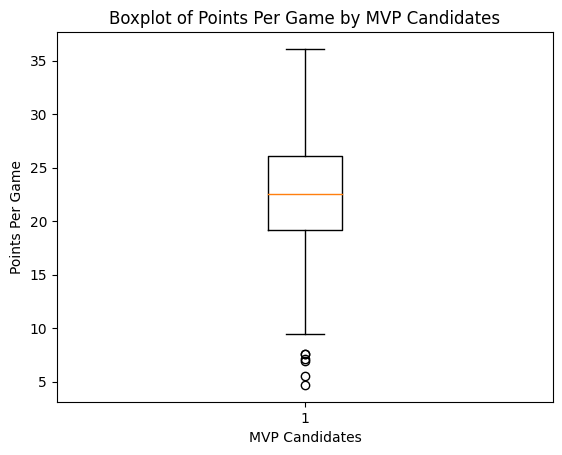

```python
import matplotlib.pyplot as plt
plt.boxplot(mvp_df['Points_Per_Game'])
plt.xlabel('MVP Candidates')
plt.ylabel('Points Per Game')
plt.title('Boxplot of Points Per Game by MVP Candidates')
plt.show()
```

```python
from scipy.stats import norm
mean = mvp_df['Points_Per_Game'].mean()
std = mvp_df['Points_Per_Game'].std()
mvp_df['Z-score'] = (mvp_df['Points_Per_Game'] - mean) / std
mvp_df['P-value'] = norm.cdf(mvp_df['Z-score'])
# Retain those that are an MVP OR retain those that are not outliers when considering PTS statistic
mvp_df = mvp_df[(mvp_df['P-value'] > 0.05) | (mvp_df['is_mvp'] == 1)]
columns_to_drop = ['Z-score','P-value']
mvp_df = mvp_df.drop(columns=columns_to_drop)
mvp_df.head()
```

|  | Player | Age | Games_Played | Minutes_Per_Game | Points_Per_Game | Rebounds_Per_Game | Assists_Per_Game | Steals_Per_Game | Blocks_Per_Game | FG% | 3P% | FT% | WS/48 | Year | is_mvp |
| --- | --- | --- | --- | --- | --- | --- | --- | --- | --- | --- | --- | --- | --- | --- | --- |
| 0 | Michael Jordan | 27 | 82 | 37.0 | 31.5 | 6.0 | 5.5 | 2.7 | 1.0 | 0.539 | 0.312 | 0.851 | 0.321 | 1991 | 1 |
| 1 | Magic Johnson | 31 | 79 | 37.1 | 19.4 | 7.0 | 12.5 | 1.3 | 0.2 | 0.477 | 0.320 | 0.906 | 0.251 | 1991 | 0 |
| 2 | David Robinson | 25 | 82 | 37.7 | 25.6 | 13.0 | 2.5 | 1.5 | 3.9 | 0.552 | 0.143 | 0.762 | 0.264 | 1991 | 0 |
| 3 | Charles Barkley | 27 | 67 | 37.3 | 27.6 | 10.1 | 4.2 | 1.6 | 0.5 | 0.570 | 0.284 | 0.722 | 0.258 | 1991 | 0 |
| 4 | Karl Malone | 27 | 82 | 40.3 | 29.0 | 11.8 | 3.3 | 1.1 | 1.0 | 0.527 | 0.286 | 0.770 | 0.225 | 1991 | 0 |

**Hypothesis Test 1:**

- We will be performing a Hypothesis Test to determine if there is a statistically significant corelation between the Points Per Game (PTS) & Assists Per Game (AST).
- H0: There is not a statistically significant correlation between Points Per Game and Assists Per Game.
- HA: There is a statistically significant correlation between Points Per Game and Assists Per Game.

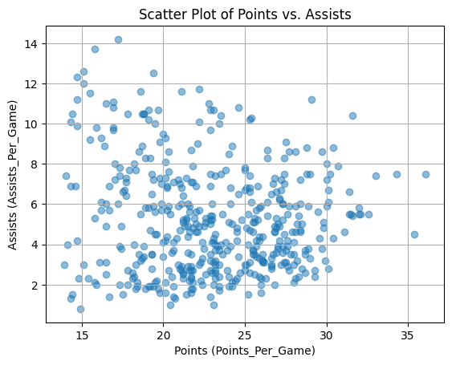

```python
from scipy.stats import pearsonr
import numpy as np
plt.scatter(mvp_df['Points_Per_Game'], mvp_df['Assists_Per_Game'], alpha=0.5)
plt.title('Scatter Plot of Points vs. Assists')
plt.xlabel('Points (Points_Per_Game)')
plt.ylabel('Assists (Assists_Per_Game)')
plt.grid(True)
plt.show()
correlation_coefficient, p_value = pearsonr(mvp_df['Points_Per_Game'], mvp_df['Assists_Per_Game'])
if p_value < 0.05:
  print("")
  print("Reject Null Hypothesis")
  print("Correlation Coefficient:", correlation_coefficient)
else:
  print("Acceept Null Hypothesis")
```

**Hypothesis Test 2:**

- We will be performing an one-way ANOVA test to see if there is a statistically significant difference between the mean Points Per Game across different seasons. This analysis will determine if there is a shift in player performance over the years.
- HO: There is not a statistically significant difference between the mean Points Per Game across seasons.
- HA: There is a statistically significant difference between the mean Points Per Game across seasons.

```python
from scipy.stats import f_oneway
from statsmodels.stats.multicomp import pairwise_tukeyhsd
f_statistic, p_value = f_oneway(
    mvp_df['Points_Per_Game'][mvp_df['Year'] == 1991],
    mvp_df['Points_Per_Game'][mvp_df['Year'] == 1992],
    mvp_df['Points_Per_Game'][mvp_df['Year'] == 1993],
    mvp_df['Points_Per_Game'][mvp_df['Year'] == 1994],
    mvp_df['Points_Per_Game'][mvp_df['Year'] == 1995],
    mvp_df['Points_Per_Game'][mvp_df['Year'] == 1996],
    mvp_df['Points_Per_Game'][mvp_df['Year'] == 1997],
    mvp_df['Points_Per_Game'][mvp_df['Year'] == 1998],
    mvp_df['Points_Per_Game'][mvp_df['Year'] == 1999],
    mvp_df['Points_Per_Game'][mvp_df['Year'] == 2000],
    mvp_df['Points_Per_Game'][mvp_df['Year'] == 2001],
    mvp_df['Points_Per_Game'][mvp_df['Year'] == 2002],
    mvp_df['Points_Per_Game'][mvp_df['Year'] == 2003],
    mvp_df['Points_Per_Game'][mvp_df['Year'] == 2004],
    mvp_df['Points_Per_Game'][mvp_df['Year'] == 2005],
    mvp_df['Points_Per_Game'][mvp_df['Year'] == 2006],
    mvp_df['Points_Per_Game'][mvp_df['Year'] == 2007],
    mvp_df['Points_Per_Game'][mvp_df['Year'] == 2008],
    mvp_df['Points_Per_Game'][mvp_df['Year'] == 2009],
    mvp_df['Points_Per_Game'][mvp_df['Year'] == 2010],
    mvp_df['Points_Per_Game'][mvp_df['Year'] == 2011],
    mvp_df['Points_Per_Game'][mvp_df['Year'] == 2012],
    mvp_df['Points_Per_Game'][mvp_df['Year'] == 2013],
    mvp_df['Points_Per_Game'][mvp_df['Year'] == 2014],
    mvp_df['Points_Per_Game'][mvp_df['Year'] == 2015],
    mvp_df['Points_Per_Game'][mvp_df['Year'] == 2016],
    mvp_df['Points_Per_Game'][mvp_df['Year'] == 2017],
    mvp_df['Points_Per_Game'][mvp_df['Year'] == 2018],
    mvp_df['Points_Per_Game'][mvp_df['Year'] == 2019],
    mvp_df['Points_Per_Game'][mvp_df['Year'] == 2020],
    mvp_df['Points_Per_Game'][mvp_df['Year'] == 2021]
)

if p_value < 0.05:
    # If p-value is significant, perform Tukey's HSD test
    tukey_results = pairwise_tukeyhsd(mvp_df['Points_Per_Game'], mvp_df['Year'])
    print("Reject the Null Hypothesis")
    print(tukey_results.summary())
else:
    print("Accept the Null Hypothesis.")
```

[output not shown]

[output cut: 458 more lines]

- After running this One-Way ANOVA Test, and getting a P-value we can see that there is a statistically significant difference between the means of the groups over the years suggesting that there is a shift in the performance of the players. Looking at the results of the PairWise Turkey HSD Test one of the most significant differences was between the years of 1999 & 2017.
- We will visualize this difference in order to put it more into perspective.

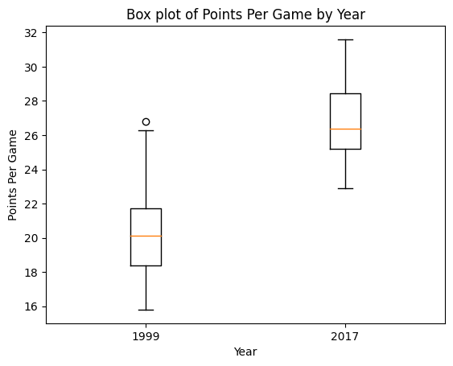

```python
pts_1999 = mvp_df[mvp_df['Year'] == 1999]['Points_Per_Game']
pts_2017 = mvp_df[mvp_df['Year'] == 2017]['Points_Per_Game']
plt.boxplot([pts_1999, pts_2017], labels=['1999', '2017'])
plt.title('Box plot of Points Per Game by Year')
plt.xlabel('Year')
plt.ylabel('Points Per Game')
plt.show()
```

# **Primary Analysis:**

- Machine Learning Model: Random Forest Classifier
- Reasoning: This machine learning model works good for Classification tasks such as the one needed to answer the question proposed. This is because we expect this Machine Learning Model to be able to pick up on the trends underlying the data that influence the MVP candidate ranking. Using a Random Forest Classifier also provides us with an advantage when dealing with this kind of High Dimensional Data since computation will become expensive with models like KNN where the entire training dataset is stored. Using a Random Forest Classifier will also allow us to gather insight on feature importance which can help with the Insights/Conclusion Section.

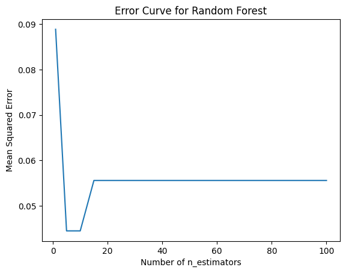

```python
from sklearn.model_selection import train_test_split
from sklearn.ensemble import RandomForestClassifier
from sklearn.metrics import mean_squared_error
X = mvp_df[['Age', 'Games_Played', 'Minutes_Per_Game', 'Points_Per_Game', 'Rebounds_Per_Game', 'Assists_Per_Game',
        'Steals_Per_Game', 'Blocks_Per_Game', 'FG%', '3P%', 'FT%', 'WS/48']]
y = mvp_df['is_mvp']
X_train, X_test, y_train, y_test = train_test_split(X, y, test_size=0.2)
n_estimators_value = [1,5,10,15,20,25,30,35,40,45,50,55,60,65,70,75,80,85,90,95,100]
MSE_error_values = []
for value in n_estimators_value:
  rfc = RandomForestClassifier(n_estimators=value,random_state=10)
  rfc.fit(X_train, y_train)
  y_pred = rfc.predict(X_test)
  mse = mean_squared_error(y_test, y_pred)
  MSE_error_values.append(mse)
plt.plot(n_estimators_value, MSE_error_values)
plt.xlabel('Number of n_estimators')
plt.ylabel('Mean Squared Error')
plt.title('Error Curve for Random Forest')
plt.show()
```

**Final Primary Analysis:**

```python
rfc = RandomForestClassifier(n_estimators=15,random_state=10)
rfc.fit(X_train, y_train)
```

```
RandomForestClassifier(n_estimators=15, random_state=10)
```

```python
features = ['Age', 'Games_Played', 'Minutes_Per_Game', 'Points_Per_Game', 'Rebounds_Per_Game', 'Assists_Per_Game',
        'Steals_Per_Game', 'Blocks_Per_Game', 'FG%', '3P%', 'FT%', 'WS/48']
print(features)
print(rfc.feature_importances_)
```

```
['Age', 'Games_Played', 'Minutes_Per_Game', 'Points_Per_Game', 'Rebounds_Per_Game', 'Assists_Per_Game', 'Steals_Per_Game', 'Blocks_Per_Game', 'FG%', '3P%', 'FT%', 'WS/48']
[0.0437584  0.03988885 0.04685495 0.15533552 0.08625864 0.0812521
 0.04018896 0.0464897  0.05869052 0.04523672 0.03625017 0.31979548]
```

# **Visualization:**

- From calling feature importance, we see that the two highest values correspond to the highest importance columns which are Points_Per_Game & WS/48. So we will create a scatter plot to visualize the differences between the values of those that are MVP's and those that are not MVP's for these two corresponding column values (Points_Per_Game & WS/48).

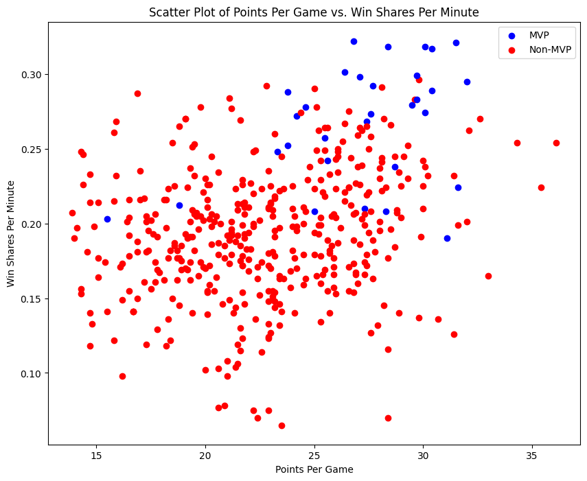

```python
plt.figure(figsize=(10, 8))
for i in range(len(mvp_df)):
    if mvp_df['is_mvp'].iloc[i]:
        plt.scatter(mvp_df['Points_Per_Game'].iloc[i], mvp_df['WS/48'].iloc[i], color='blue')
    else:
        plt.scatter(mvp_df['Points_Per_Game'].iloc[i], mvp_df['WS/48'].iloc[i], color='red')

plt.xlabel('Points Per Game')
plt.ylabel('Win Shares Per Minute')
plt.title('Scatter Plot of Points Per Game vs. Win Shares Per Minute')
plt.legend(['MVP', 'Non-MVP'])
```

- From the scatter plot above we can see that what differentiates an MVP from a Non-MVP is a high Win Share percentage and a high Points Per Game value. However, we do notice some variation in the data in the sense that sometimes even players with high Points Per Game and a high Win Share Percentage are not MVP's. This variation that we see in this scatter plot highlight the fact that there are other factors that come into play besides just these two columns. This further emphasizes why the MVP selection criteria is a nuanced process. Additionally, the variation can be attributed to the results of our Hypothesis Test 2 which indicated that there has been a notable shift in the way that basketball has been played. This emphasizes the need for historical context when analyzing sports data since there has been a shift in the basketball landscape over time.

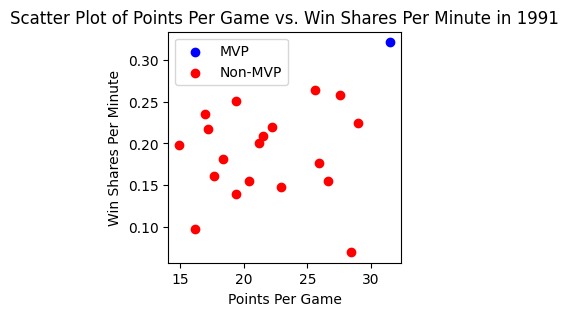

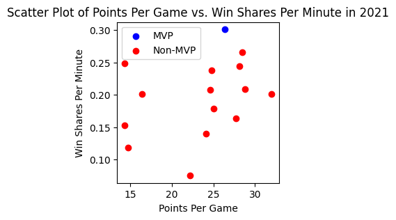

```python
years_arr = [1991,2021]
for year in years_arr:
  plt.figure(figsize=(3, 3))
  for i in range(len(mvp_df)):
    if mvp_df['Year'].iloc[i] == year:
      if mvp_df['is_mvp'].iloc[i]:
        plt.scatter(mvp_df['Points_Per_Game'].iloc[i], mvp_df['WS/48'].iloc[i], color='blue')
      else:
        plt.scatter(mvp_df['Points_Per_Game'].iloc[i], mvp_df['WS/48'].iloc[i], color='red')

      plt.xlabel('Points Per Game')
      plt.ylabel('Win Shares Per Minute')
      plt.title(f"Scatter Plot of Points Per Game vs. Win Shares Per Minute in {year}")
      plt.legend(['MVP', 'Non-MVP'])
```

- This visualization provides insight to the historical context in which we can notice a shift from how the trend for choosing the MVP has shifted over time yet the MVP always remains in the top right quadrant. Suggesting that while Win Share and Points Per Game are crucial, they are not the end all be all and that there are other factors that need to be considered emphasizing the need for machine learrning to understand these multiple dimensions. This is supported by the values of RandomForest.features*importance* which assigned importance of 0.32 and 0.16 to Win Share and Points Per Game respectively. These values do not indicate clear dominance emphasizing the need for other dimensions.

# **Insights & Conclusions:**

- The uninformed reader has beeen walked through the Data Science Life Cycle consisting of Data Curation, to Data Exploratiton to Primary Analaysis and Visualization.
- A reader who already knew about what differentiates NBA MVP selection will understand that there is a shift in the way that the sport of basketball is fundementally played and will acknowledge a difference in the statistics gather during the early era's of basketball compared to know is due to this shift in the sport.